# Detecting and locating chess pieces using Convolutional Neural Networks (CNN) and YOLO5 with Ultralytics

2025-11-17

```python
!git clone https://github.com/ultralytics/yolov5  # Clone repository
%cd yolov5
!pip install -r requirements.txt  # Install dependencies
```

## Introduction to some Computer Vision concepts

**Ziel**: Schachfiguren auf einem Schachbrett erkennen

- früher: vorgegebene Objekte einfach Bildern finden
- man kann ein Bild/icons ausschneiden und dieses in einem anderen Bild finden

**Nachteil** - dieses Bild musste dem Image in einem anderen Bild sehr ähnlich sein (hing u.a. an einem vorgegebenen *similarity threshold* ab)

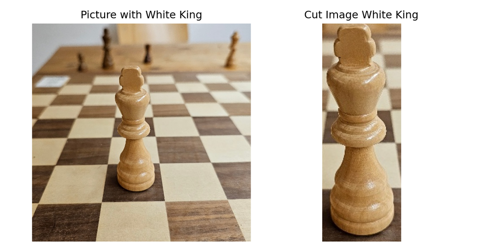

```python
kingscr = cv.matchTemplate(whiteking, cut_rgb ,cv.TM_CCOEFF_NORMED)
threshold = 0.7
locback = np.where(kingscr >= threshold)
locback = np.array(locback)


# Draw a rectangle around the detected object
color = (0, 255, 0)  # Green color in BGR
thickness = 2  # Thickness of the rectangle border
cv.rectangle(whiteking, (locback[1][0], locback[0][0]), (locback[1][0] + 109, locback[0][0] + 303), color, thickness)
```

```python
# Convert from BGR to RGB with openCV
img_rgb = cv.cvtColor(whiteking, cv.COLOR_BGR2RGB)

# Display the image
plt.imshow(img_rgb)
plt.axis('off')  # Hide axes
```

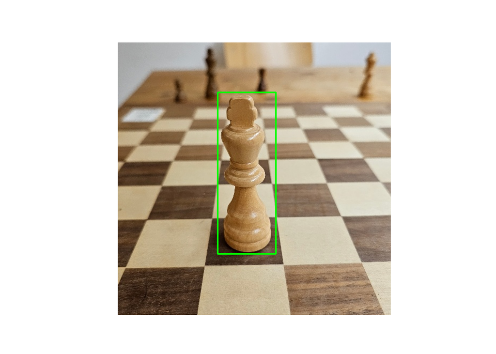

```python
plt.show()
```

```python
# Convert to grayscale
gray = cv.cvtColor(whiteking1, cv.COLOR_BGR2GRAY)

# Apply Gaussian Blur to reduce noise
blurred = cv.GaussianBlur(gray, (5, 5), 0)

# Perform edge detection (Canny)
edges = cv.Canny(blurred, 50, 150)

# Find contours
contours, hierarchy = cv.findContours(edges, cv.RETR_TREE, cv.CHAIN_APPROX_SIMPLE)

whiteking1 = cv.cvtColor(whiteking1, cv.COLOR_BGR2RGB)
# Draw all contours on the original image
output = whiteking1.copy()

# Display the image
plt.imshow(cv.drawContours(output, contours, -1, (0, 255, 0), 2))
plt.axis('off')  # Hide axes
```

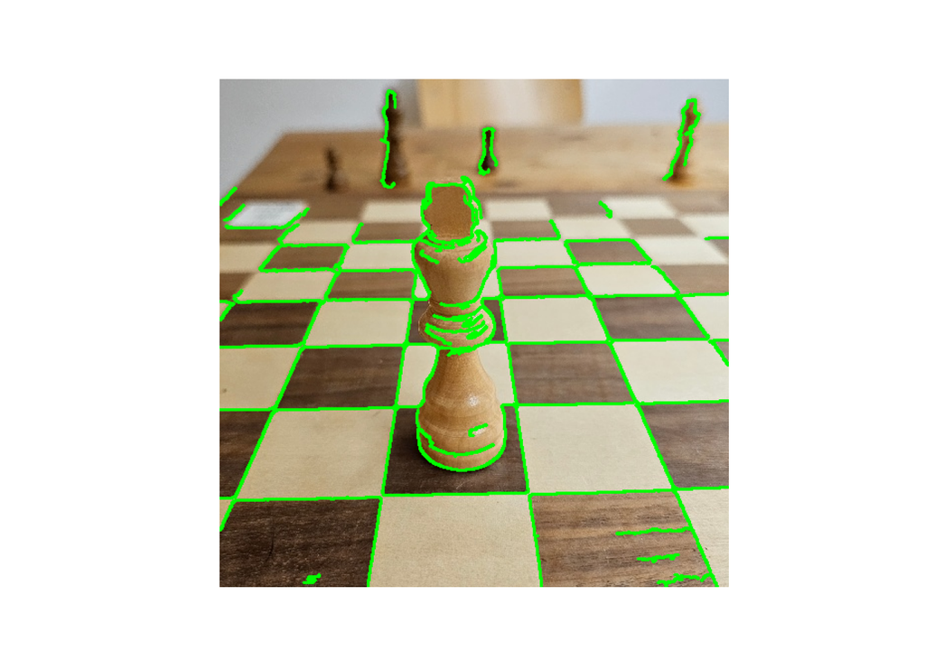

```python
plt.show()
```

Simple **Algorithmen** zur Objekterkennung - Lernen nicht - vorgegebene Objekte erkennen (müssen sehr ähnlich sein) - Erkennen, dass Objekte auf dem Bild sind -
$$\rightarrow$$
Einschränkungen bei der Erkennung und Identifizierung von Objekttypen 1. CNN: hier verschiedene Schachfiguren kategorisieren 2. YOLO5, Ultralytics: mehrere verschiedene Schachfiguren auf einem Schachbrett finden und kategorisieren

## CNN: Convolutional Networks

- Bilder kategorisieren
- ähnliche Bilder von einem bestimmten Objekttyp (Katze, Hund, Alpaka) in einem Foto identifizieren

## Datenvorbereitung

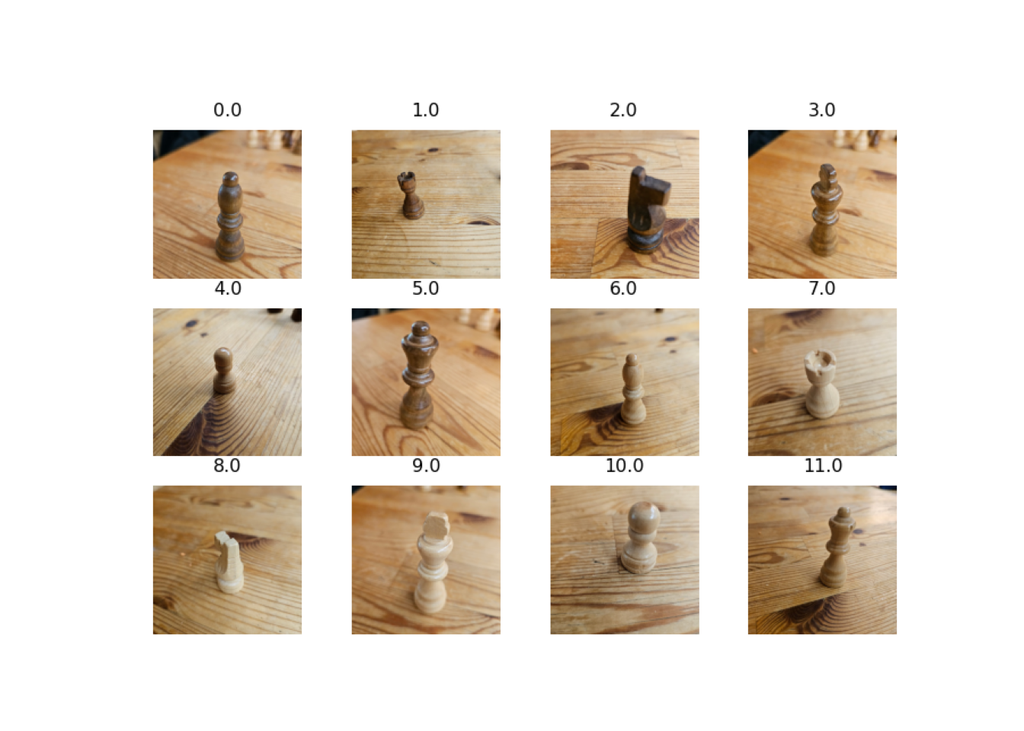

- Funktion die alle Bilder in einem np.array zusammenführt und als Variable x zurückgibt
- y sind jeweiligen Ziellabels zu den jeweiligen Bildern

```python
import os
import numpy as np
from PIL import Image

# Function to load images into a NumPy list
def load_images(image_folder):
    images = []

    for filename in os.listdir(image_folder):
        if filename.endswith(('.jpg')):
            image_path = os.path.join(image_folder, filename)

            # Open image and convert to NumPy array
            img = Image.open(image_path)
            img_array = np.array(img)

            # Append the image array to the list
            images.append(img_array)

    return images
images = load_images("pics")
images = np.array(images)
x = images
y = np.loadtxt("y.txt")
```

Diese werden weiter für das CNN vorbereitet:

```python
import tensorflow as tf
import numpy as np
import matplotlib.pyplot as plt
from tensorflow.keras.preprocessing.image import load_img
from tensorflow.keras.preprocessing.image import img_to_array

from sklearn.preprocessing import LabelBinarizer
from tensorflow import keras
from sklearn.model_selection import train_test_split
from sklearn.metrics import confusion_matrix, ConfusionMatrixDisplay
from tensorflow.keras import layers, models
from tensorflow.keras.utils import to_categorical
import io
import time
import os



# Durchführen eines Train Test Splits
X_train, X_test, y_train,y_test = train_test_split(x, y, test_size=0.2, random_state=42)

# y-train werden one-hot encoded, da 12 Klassen kategorisiert werden sollen
lb = LabelBinarizer()
y_train = lb.fit_transform(y_train)
y_test = lb.transform(y_test)
```

## Model Building

```python
# Build the CNN model
model = models.Sequential([
    layers.Input(shape=(224, 224, 3)),           # <- add this
    layers.Conv2D(32, (3, 3), activation='relu'),
    layers.MaxPooling2D((2, 2)),
    layers.Conv2D(64, (3, 3), activation='relu'),
    layers.MaxPooling2D((2, 2)),
    layers.Flatten(),
    layers.Dense(128, activation='relu'),
    layers.Dropout(0.5),
    layers.Dense(12, activation='softmax'),
])

model.compile(optimizer='adam', loss='categorical_crossentropy', metrics=['accuracy'])

model.summary()

# Train the model
history = model.fit(X_train, y_train, epochs=20, batch_size=2, validation_data=(X_test, y_test))

y_pred = model.predict(X_test)
```

**Ergebnisse des CNN Trainings:**

**Validation Training Results**

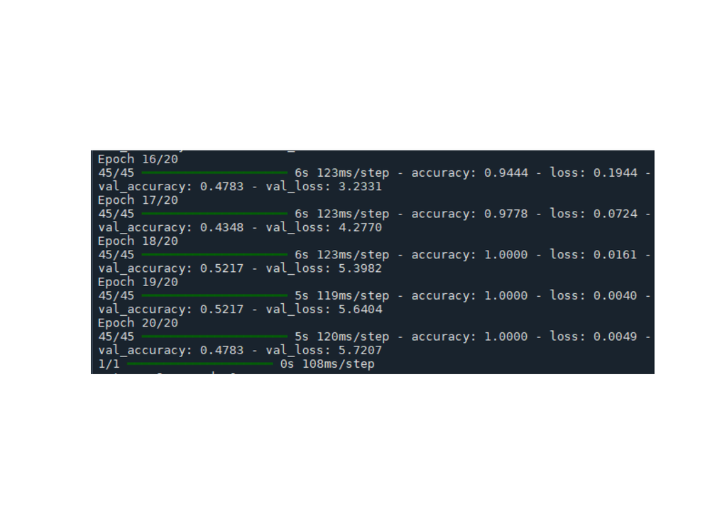

**Prediction Results**

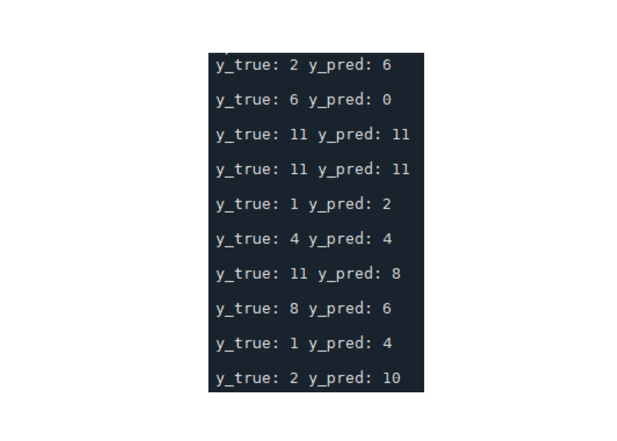

## Interpretation der Ergebnisse

Die Ergebnisse mit CNNs sind nicht zufriedenstellend. Es wird etwas gelernt, aber das Ergebnis ist für das Ziel nicht brauchbar. Das liegt sehr wahrscheinlich an der Qualität der Bilder, auf denen das CNN gelernt hat. Da bei jedem Bild ein unterschiedlicher Hintergrund präsentiert wird, wird dieser für jedes Bild mit gelernt. Hier sollten die Bilder mit einem identischen Hintergrund fotografiert werden. Das gelernte Modell scheint dann aber für den praktischen Einsatz ungeeignet, da die Bilder nur mit einem einheitlichen Hintegrund gelernt werden. Das ist im Einsatz beim Schachspiel nicht praktikabel.Der Einsatz von CNN für eine einfache Kategorisierung einzelner Schachfiguten scheint, wie hier dargestellt, keine geeignete diese Aufgabe zu sein.

YOLO5 und Ultralytics bieten die Möglichkeit mehrere Objekte in einem variablen Bild identifizieren zu können.

# YOLO5 und Ultralytics

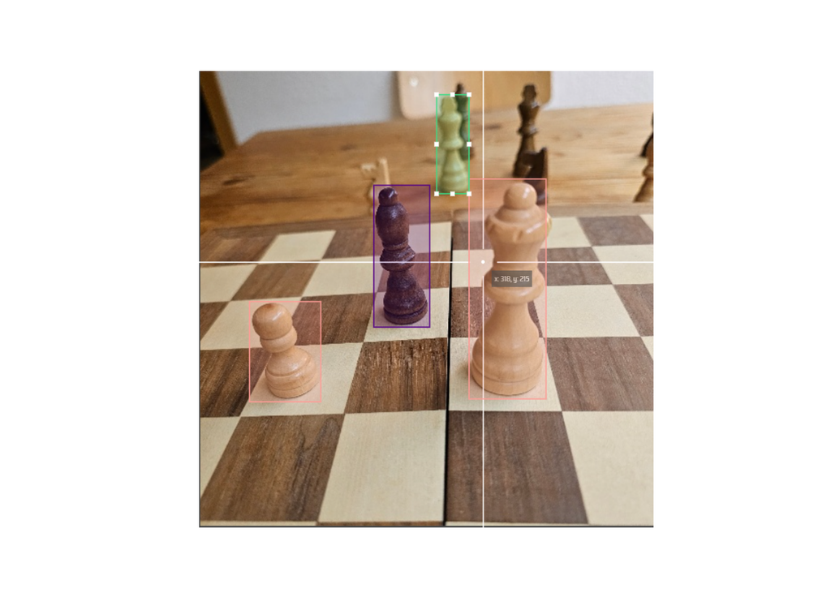

Die Bilder werden in Ultralytics (hier auf Google Colab) aufgeteilt in einen Ordner *Images* und einen Ordner *Labels*. Der Ordern Images enthält Unterordner mit den Trainingsbilder in *train* und den Validationbildern in *val*. In Labels werden die Labels den jeweiligen Bildern entsprechend auch unter *train* und unter *val* gespeichert.

- Images
  - train
  - val
- Labels
  - train
  - val

**yaml** Datei erstellen

Es muss außerdem noch eine *yaml* Datei erstellt werden, um;

- die Pfade zu den Images und den Label Ordnern zu übergen
- die Anzahl der Kategorien und der Kategorienauflistung mit Namen

Auf die Yaml Datei wird dann im Hauptprogramm verwiesen.

**Code für Training**

```python
!git clone https://github.com/ultralytics/yolov5  # Clone repository
%cd yolov5
!pip install -r requirements.txt  # Install dependencies

from ultralytics import YOLO
from google.colab import drive

drive.mount('/content/drive')

# Ein trainiertes Modell von YOLO5 laden
# und für Transfer-Learning verwenden
model = YOLO("yolov5s.pt")

# Das Modell auf die eigenen Bilder trainieren
# 10 epochen - mehr bringt auch nicht mehr
# batch size 10 - bessere Übersicht
# save_json: Ergebnisse in einer Json Datei ausgeben
# ansonsten wird auch automatisch eine .csv Datei erstellt

results = model.train(data="ChessPieces.yaml",
                      epochs=10,
                      imgsz = 256,
                      batch = 10,
                      save_json = True,
                      lr0=0.05,
                      augment=True,
##                      flipud=0.5,
##                      fliplr=0.5,
##                      degrees=5
##                      scale=0.1
)

# check prediction of model for white rook in data set
result = model.predict(r"images/val/whitecastle2.jpg",
                       save=True,
                       imgsz = 256,
                       conf=0.45,  # Schwellenwert 1 nur Obekte mit höchster Wahrscheinlichekit über diesem Wert behalten
                       iou=0.5,  # Schwellenwert 2 Objekte die sich mit IOU größer diesem Wert überlappen entfernen
                       )
```

## Predict Ergebnis des einen Beispiels

- Es wurde geprüft, ob ein weißer Turm erkannt wird. Zusätzlich gibt das System zurück, wie sicher es in seiner Kategorisierung ist, die richtige Entscheidung getroffen zu haben.

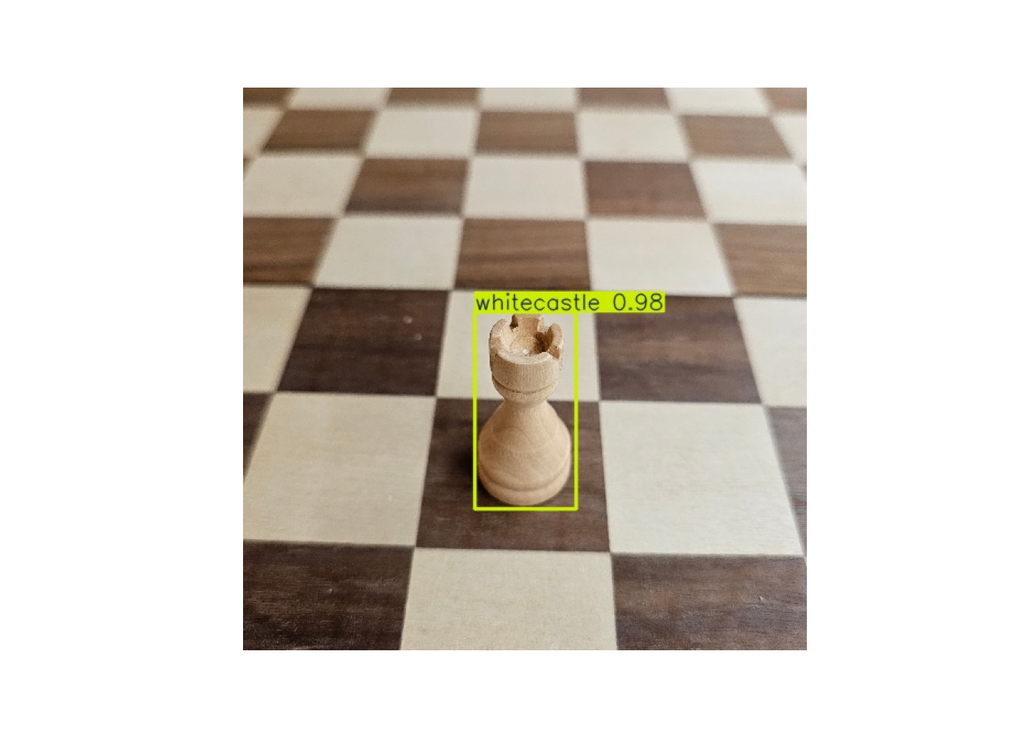

## Confusion Matrix

- Anzeige einer normalisierten Confusion Matrix der Ergebnisse
- einige wenige Schachfiguren werden gut erkannt
- andere gar nicht sicher

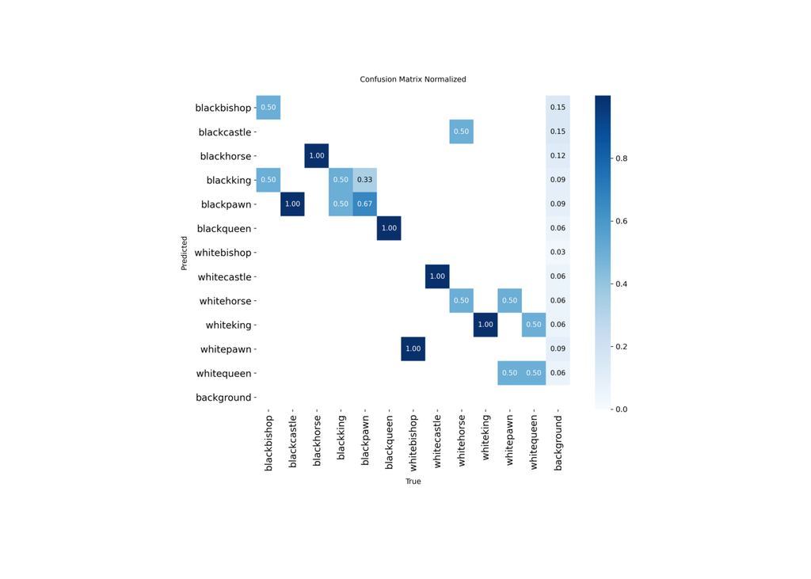

## Training Pictures augmented

Im Trainingsset wurden die Bilder *augmented* also mit verschiedenen variablen Verzerrungen versehen (z.B. verschoben, gedreht)

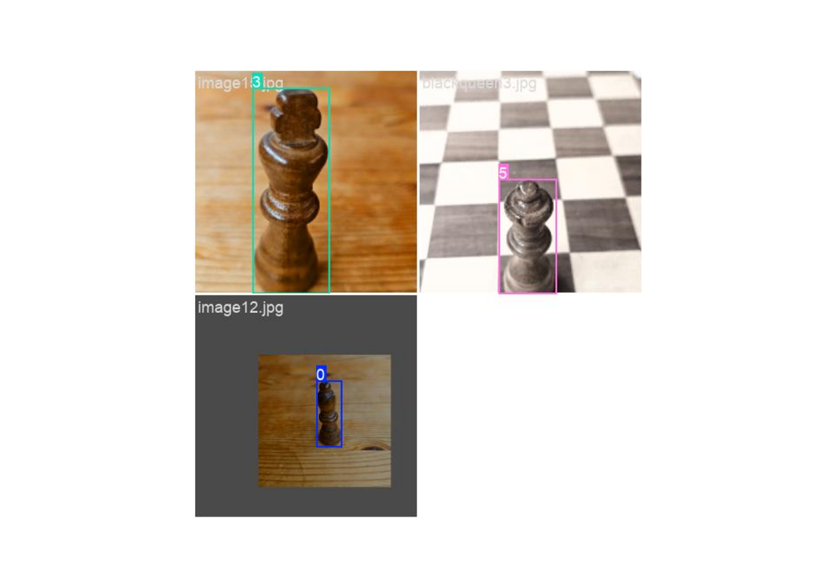

## Evaluation Pictures

Hier ist das Ergebnis, wie die Schachfiguren in verschiedenen Bildern erkannt werden.

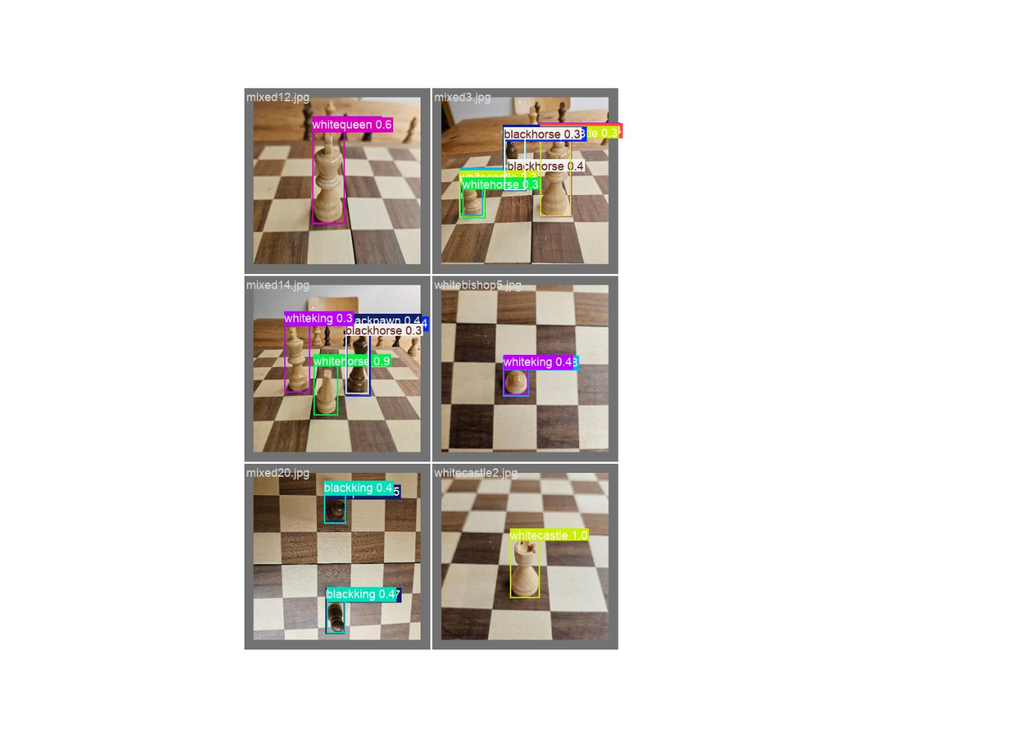

- Die Erkennung ist noch nicht besonders gut. Wahrscheinlich zu viel Rauschen durch das Fotografieren einiger Schachfiguren von oben.
- $\rightarrow$ Bilder, die von oben fotografiert wurden, sollten erstmal nicht in das Modell einfliessen
- Außerdem ist das aufgenommene Dataset noch immer zu klein, um zuverlässige Ergebnisse zu liefern.
  - 120 Bilder insgesamt
- $\rightarrow$ mit deutlich mehr Bildern trainieren, um die Variabilität von den unterschiedlichen Perspektiven auzugleichen

## What next?

- Mehr Bilder machen
- Bilder, die von oben fotografiert sind, erstmal rausnehmen

### Großes Ziel, viele Herausforderungen

- Schachbrett separat trainieren?
- Wie werden Positionen der Felder ermittelt?
- Positionen der Figuren auf dem Schachbrett ermitteln

### Mögliche Ideen

- Felder auf dem gesamtes Schachbrett mit openNCV erkennen
- Felder benennen - Koordinaten bestimmen
- Diese dann mit Figuren trainieren
- Fehlende Bereiche des Schachbretts füllen - z.B. mit Generative Adversarial Networks (GANs)